# HW 2: Exploration

Load Libraries

```r
#libraries:
library(tidyverse)   # dplyr, purrr, etc.
library(janitor)     # for clean_names()
library(lubridate)   # for mdy(), etc
library(here)        # for here()
library(sf)          # spatial data
library(doBy)        # for summaryBy()
```

## 0.1 AQI

### 0.1.1 Median AQI

```r
# data ranges from 2000 - 2024
years <- 2000:2024

# -------- S E T  U P  L O O P  --------
median_aqi_list <- map(years, ~ {

      # build the file path
  aqi_file_path <- here("data/aqi_daily", paste0("aqidaily_", .x, ".csv"))

# -------- R E A D  I N  D A T A --------
  read_csv(aqi_file_path) %>%
    clean_names() %>%

# -------- T I D Y--------
      #transform date from a character to a date
    mutate(date = mdy(date)) %>%

      #extract year
    mutate(year = year(date)) %>%

      #calculate median AQI
    group_by(year) %>%
    summarize(
      median_aqi = median(overall_aqi_value, na.rm = TRUE),
      .groups = "drop")

})

# combine into one data frame
median_aqi_df <- bind_rows(median_aqi_list)
```

### 0.1.2 Visualize

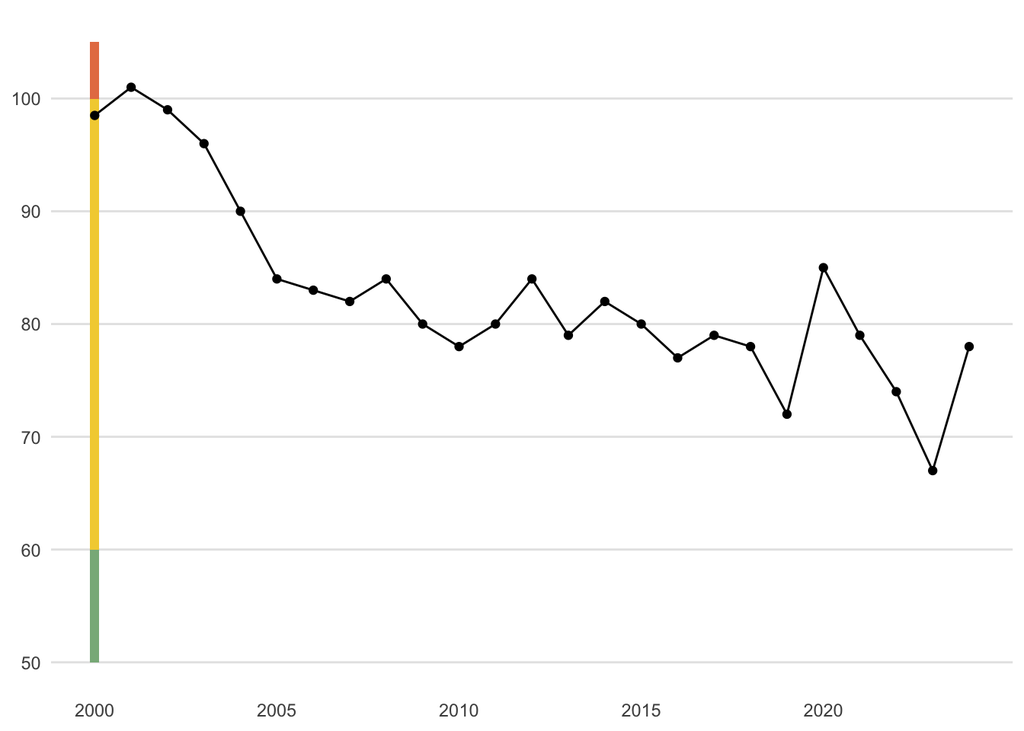

```r
ggplot(median_aqi_df, aes(x = year, y = median_aqi)) +
  labs(x = " ", y = "Median AQI") +

  # Add colored axis lines
  geom_segment(aes(x = 2000, xend = 2000, y = 50, yend = 60), color = "#88B589", linewidth = 2) +
  geom_segment(aes(x = 2000, xend = 2000, y = 60, yend = 100), color = "#F3D03E", linewidth = 2) +
  geom_segment(aes(x = 2000, xend = 2000, y = 100, yend = 105), color = "#E67E52", linewidth = 2) +

  geom_line() +
  geom_point() +

  scale_y_continuous(
    limits = c(50, 105),
    breaks = seq(50, 100, by = 10)
  ) +

  scale_x_continuous(
    limits = c(2000, 2024),
    breaks = seq(2000, 2024, by = 5)
  ) +

  theme_minimal() +

  theme(
    panel.grid.major.y = element_line(color = "gray90"),
    panel.grid.minor.y = element_blank(),
    panel.grid.minor.x = element_blank(),
    panel.grid.major.x = element_blank(),

    axis.line.y = element_blank(),

    axis.title = element_blank(),   # Remove axis titles

  )
```

nice colors: # Add colored axis lines geom_segment(aes(x = 2000, xend = 2000, y = 50, yend = 60), color = “#F3D03E”, linewidth = 2) + geom_segment(aes(x = 2000, xend = 2000, y = 60, yend = 100), color = “#9BC4A7”, linewidth = 2) + geom_segment(aes(x = 2000, xend = 2000, y = 100, yend = 105), color = “#E88D67”, linewidth = 2) +

Notes: fix scaling, aspect, overlay EPA’s air quality standards as a reference line.

Events: California Diesel Risk Reduction Program (2000), 2005: The SCAQMD developed Clean Fleet rules to reduce diesel exhaust, decomissioning coal plants (?), 2003, SCAQMD implemented “Check Before You Burn, 2020 spike due to wildfire (?)

### 0.1.3 Main Pollutant in AQI

```r
# -------- S E T  U P  L O O P  --------
common_pollutant_list <- map(years, ~ {

  # file path
  aqi_file_path <- here("data/aqi_daily", paste0("aqidaily_", .x, ".csv"))

  # -------- R E A D  I N  D A T A --------
  read_csv(aqi_file_path) %>%
    clean_names() %>%

    # character to date
    mutate(date = mdy(date)) %>%

    # extract year
    mutate(year = year(date)) %>%

    select(year, main_pollutant)

})

# Combine all common pollutant calculations into one data frame
common_pollutant_all <- bind_rows(common_pollutant_list)
```

### 0.1.4 Visualize 1.0

```r
ggplot(common_pollutant_all, aes(x = main_pollutant)) +
  geom_bar() +
  coord_flip()
```

```r
# ---------- SUMMARIZE BY YEAR ---------

# count occurrences of pollutants for the year
top_pollutants <- common_pollutant_all %>%
  group_by(year, main_pollutant) %>%
  summarize(count = n(), .groups = "drop") %>%

  group_by(main_pollutant) %>%
  summarize(avg_count = mean(count), .groups = "drop")
```

### 0.1.5 Visualize 2.0

```r
library(dplyr)
library(packcircles)
library(ggplot2)

# -------- STEP 1:Compute circle layout----------

# circleProgressiveLayoutcalculates the positions and sizes of circles to create a non-overlapping
circle_layout <- circleProgressiveLayout(top_pollutants$avg_count, sizetype = "area")

# Add a small gap between circles
circle_layout$radius <- circle_layout$radius * 0.95

# Add coordinates back to the pollutant data
circle_data <- cbind(top_pollutants, circle_layout)

# create vertices for circle polygons
circle_vertices <- circleLayoutVertices(circle_layout, npoints = 50)

# -------- STEP 2: ADD NESTED CIRCLES ----------
# Generate radius, x, and y coordinates for nested circles
circle_layout_border <- circle_layout
circle_layout_border$radius <- circle_layout$radius * 0.95

# Create vertices for nested circles
circle_vertices_border <- circleLayoutVertices(circle_layout_border, npoints = 50)

# # -------- STEP 3: JOIN TABLES TO ADD LABELS ----------
#
# Combine the pollutant data with circles (center coordinates and radius)
circle_labels <- cbind(top_pollutants, circle_layout)
```

alt:

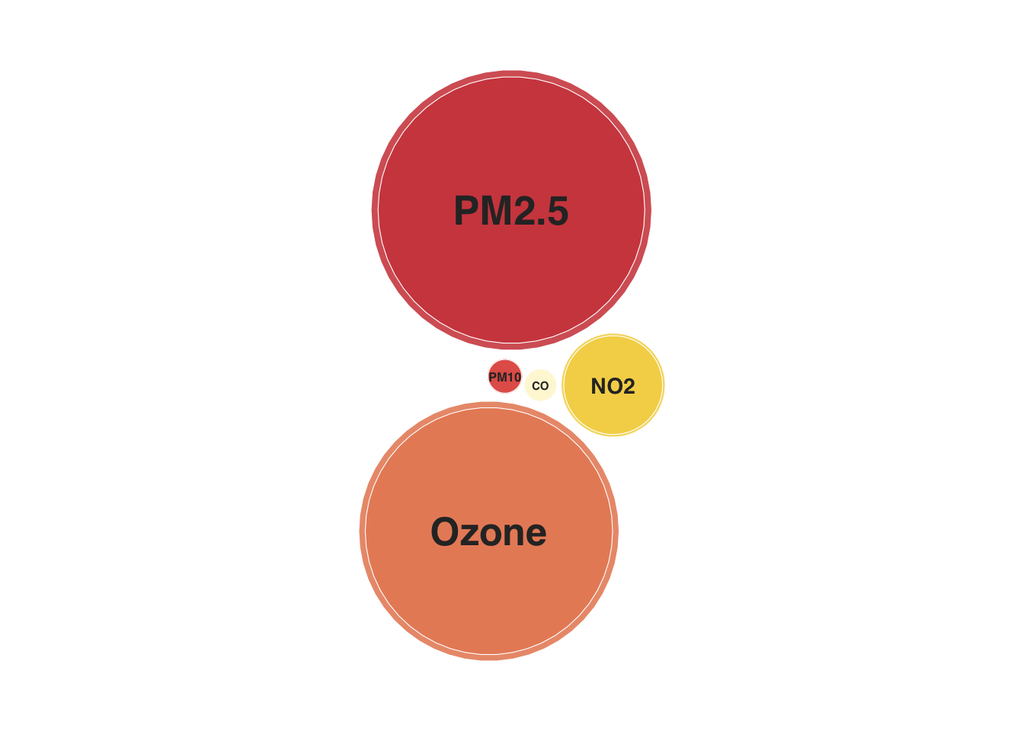

```r
pal_1 <- c("#FEF6D3", "#F3D03E", "#E67E52", "#E04D40", "#CC3333")

pal_2 <- c("#FFF2D1", "#F3D03E", "#EB865A", "#E35745", "#D42E2E")




# Create base map with improved aesthetics
gg_circles <- ggplot() +
  # Main circles with refined styling
  geom_polygon(data = circle_vertices,
               aes(x = x, y = y, group = id, fill = as.factor(id)),
               color = "white",          # White borders for cleaner look
               size = 0.2,              # Thinner border
               alpha = 0.8) +           # Slightly more opaque
  theme_void() +
  coord_equal() +
  labs(fill = "Pollutant")
# Nested circles with enhanced visual hierarchy
gg_circles_nested <- gg_circles +
  geom_polygon(data = circle_vertices_border,
               aes(x = x, y = y, group = id, fill = as.factor(id)),
               colour = "white",        # White borders to match main circles
               size = 0.2,             # Consistent border width
               alpha = 0.5) +          # Better transparency for layering
  theme_void() +
  theme(
    plot.background = element_rect(fill = "white", color = NA),
    plot.margin = margin(20, 20, 20, 20),  # Add breathing room
    panel.grid = element_blank(),          # Ensure no grid
    legend.position = "none"
  )

gg_circles_with_labels <- gg_circles_nested+
  geom_text(data = circle_labels,
            aes(x = x, y = y, size = avg_count, label = main_pollutant),
            fontface = "bold",
            family = "Helvetica",
            color = "#2F2F2F") +
  scale_fill_manual(values = pal_1) +
  scale_size_continuous(range = c(2, 7)) +
  theme_void() +
  theme(
    text = element_text(family = "Helvetica"),
    plot.background = element_rect(fill = "white", color = NA),
    plot.margin = margin(20, 20, 20, 20),
    legend.position = "none"
  )

gg_circles_with_labels
```

# 1 Individual Pollutants

## 1.1 PM 2.5 Single Pollutant

After exploring the data, I dont think I will use these datasets.

### 1.1.1 Tidy

```r
PM2_5_df <- read.csv(here("data/pm_annual.csv")) %>%
  clean_names()

PM2_5 <- PM2_5_df %>%

  # transform date from a character to a date
  mutate(date = mdy(date)) %>%

  # create new columns for month, day, and year using lubridate
  mutate(
    month = month(date),
    day   = day(date),
    year  = year(date)
  ) %>%

  # select only the columns we need
  select(daily_mean_pm2_5_concentration, units, year, month)

# -------- F I N D   A N N U A L  M E A N --------
   annual_PM2_5 <- PM2_5  %>%
  group_by(year) %>%
    summarize(
      units = first(units),
      yearly_mean_pm2_5 = mean(daily_mean_pm2_5_concentration, na.rm = TRUE),
      .groups = "drop"
    )
```

### 1.1.2 Visualize by Year

```r
ggplot(annual_PM2_5, aes(x = year, y = yearly_mean_pm2_5)) +
  geom_line() +
  geom_point() +
  labs(x = "Year", y = "Mean PM2.5 (µg/m³)") +
  theme_bw()
```

```r
ggplot(annual_PM2_5, aes(x = year, y = yearly_mean_pm2_5)) +
  geom_line() +
  geom_point() +
  labs(x = "Year", y = "Mean PM2.5 (µg/m³)") +
  theme_bw() +
  coord_fixed(ratio = 1/2) +
  scale_y_continuous(breaks = seq(0, 21, by = 5))
```

### 1.1.3 Visualize by Month

```r
monthly_PM2_5 <- PM2_5 %>%
   group_by(month) %>%
    summarize(
      units = first(units),
      monthly_mean_pm2_5 = mean(daily_mean_pm2_5_concentration, na.rm = TRUE),
      .groups = "drop"
    )
```

```r
ggplot(monthly_PM2_5, aes(x = month, y = monthly_mean_pm2_5)) +
  geom_bar(stat = "identity") +
  labs(x = "Month (2000-2024)", y = "Mean PM2.5 (µg/m³)") +
  coord_fixed(ratio = 0.5) +
  theme_bw()
```

## 1.2 Ozone

### 1.2.1 Tidy

```r
#read in data and clean names
annual_ozone <- read.csv(here("data/ozone_annual.csv")) %>%
  clean_names()

annual_ozone <- annual_ozone %>%
# transform date from a character to a date
  mutate(date = mdy(date)) %>%

# create new columns for month, day, and year using lubridate
  mutate(
    month = month(date),
    day   = day(date),
    year  = year(date)
  ) %>%

# group by year to show count of how many days per year exceed 0.070 ppm
  group_by(year) %>%
  summarize(days_over_070 = sum(daily_max_8_hour_ozone_concentration > 0.070, na.rm = TRUE))
```

### 1.2.2 Visualize

```r
# make a bar graph
ggplot(annual_ozone, aes(x = year, y = days_over_070)) +
  geom_col()
```

```r
#this is cool but id rather have it in buckets of unhealthy for sensi, unhealthy, and v unhealthy - stacked bar/area
```

# 2 Census and Socioeconomic Data

## 2.1 Enviroscreen (tabular) - Tidy

```r
# read in enviroscreen data and clean names
ES_full <- read.csv(here("data/enviroscreen/enviroscreen_csv/enviroscreen_data.csv")) %>%
  clean_names()

# ----- TIDY DATA ------
es_df <- ES_full %>%
  # filter to only show LA County
  filter(california_county == "Los Angeles") %>%
  # select for the relevant columns
  select(census_tract,
         california_county,
         total_population,
         zip,
         approximate_location,
         longitude,
         latitude,
         ozone,
         pm2_5,
         diesel_pm,
         tox_release,
         traffic,
         asthma,
         poverty,
)

# filter dataset for Los Angeles County
top_10_pm2_5  <- es_df %>%
  filter(california_county == "Los Angeles")

top_10_pm2_5 <- top_10_pm2_5  %>%
  group_by(zip) %>%
      # calculate the mean PM2.5 for each zip
  mutate(mean_pm2_5 = mean(pm2_5, na.rm = TRUE)) %>%
  ungroup() %>%
      # arrange by the mean
  arrange(desc(mean_pm2_5)) %>%
      # keep one row per zip
  distinct(zip, .keep_all = TRUE) %>%
      # select the top 10 zip codes
  slice(1:10)
```

Top 10 Zip Codes w highest mean PM 2.5:

- 91335 Reseda
- 91711 Claremont
- 91767 Pomona
- 90012 Downtown Los Angeles
- 91316 Encino
- 91766 Pomona
- 90031 Lincoln Heights –> **MY HOUSE!**
- 90071 Bunker Hill/DTLA
- 90033 Boyle Heights
- 91406 Van Nuys

## 2.2 Enviroscreen (spatial) - Tidy

```r
# --------------------Spatial Data-----------------------
# bring in enviroscreen shapefile
enviroscreen_sf <- read_sf(here("data/enviroscreen/enviroscreen_shapefiles/CES4_final_shapefile.shp")) %>%
  clean_names()

# ----- TIDY DATA ------
enviroscreen_sf <- enviroscreen_sf %>%
  # filter to only show LA County
  filter(county == "Los Angeles") %>%
  # select for the relevant columns
  select(tract,
         zip,
         approx_loc,
         ozone,
         pm2_5,
         pm2_5_p,
         diesel_pm,
         traffic,
         asthma,
         poverty,
         geometry,
         county
)
```

## 2.3 Tidy Census

```r
library(sf)
library(tidycensus)
library(tidycensus)
library(tidyverse)

### Step 1: Census data filtered to Los Angeles
# all of LA county
la_census <- tidycensus::get_acs(
  state = "CA",
  county = "Los Angeles",
  geography = "tract",
  variables = "B25004_001", ## Vacancy Status
  geometry = TRUE,
  year = 2021
)

# filtered to exclude unincorporated areas and islands
la_census_filter <- la_census %>%
  mutate(NAME = gsub(", Los Angeles County, California", # elements that you want to remove
                     "", # replace with blank
                     NAME)) %>%
  mutate(NAME = gsub("Census Tract ", # elements that you want to remove
                     "", # replace with blank
                     NAME)) %>%
  filter(GEOID != "06037599100") %>% # islands
  filter(GEOID != "06037599000") %>% # islands
  filter(GEOID != "06037980003") %>%
  filter(GEOID != "06037980004") %>%
  filter(!(NAME >= 9000 & NAME <= 9800))

### Step 2: Enviroscreen data filtered to Los Angeles
# read in and filter out areas we know we don't want
enviroscreen_sf <- enviroscreen_sf %>%
  janitor::clean_names() %>%
  filter(county == "Los Angeles") %>%
  filter(tract != 6037599100) %>% # islands
  filter(tract != 6037599000) %>% # islands
  filter(tract != 6037980003) %>% # unincorporated
  filter(tract != 6037930101) %>% # forests, unincorporated areas, etc
  filter(tract != 6037930301) %>%
  filter(tract != 6037930200) %>%
  filter(tract != 6037920303)
```

```r
### Step 3: join tidy census and enviroscreen
# set crs to be the same as la census tracts
enviroscreen_sf <- st_transform(enviroscreen_sf, st_crs(la_census_filter))

# filter out northern areas so we just have LA itself left
final_enviroscreen <- st_filter(enviroscreen_sf, la_census_filter)
```

### 2.3.1 Visualize

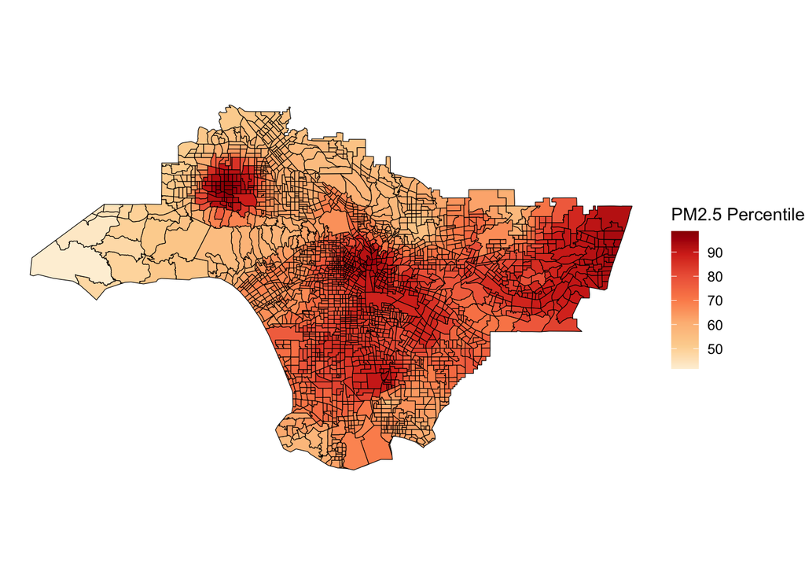

```r
# plot PM 2.5 per census tract
ggplot() +
  geom_sf(data = final_enviroscreen, aes(fill = pm2_5_p), color = 'black', size = 1) +
  scale_fill_distiller(palette = "OrRd", direction = 1) +
  theme_minimal() +
  labs(fill = "PM2.5 Percentile") +
  theme(
    legend.title = element_text(size = 12),
    legend.text = element_text(size = 10),
    axis.text = element_blank(),
    axis.title = element_blank())+
  theme_void()
```

Using percentile PM2.5 as opposed to raw PM 2.5 shows more of an EJ POV, as the percentile is a relative ranking of PM2.5 concentrations compared to other census tracts statewide. (ex: A percentile of 90 means the area has higher PM2.5 pollution than 90% of other census tracts in California.)

# 3 Pollution Sources

## 3.1 Point Sources

### 3.1.1 Tidy

```r
point_sources <- read.csv(here("data/sources/facility_point_sources_2020.csv")) %>%
  clean_names()

point_sources <- point_sources %>%
  filter(pollutant %in% c("PM2.5 Primary (Filt + Cond)", "PM2.5 Filterable"))

# split the lat_lon into two separate columns to create spatial object

point_sources <- point_sources %>%
    # Remove brackets from the lat_long column
    mutate(lat_long = gsub("\\[|\\]", "", lat_lon)) %>%
    # Separate the lat_long column into two columns: longitude and latitude
    separate(lat_long, into = c("longitude", "latitude"), sep = ",") %>%
    # Convert to numeric
    mutate(
        longitude = as.numeric(longitude),
        latitude = as.numeric(latitude)
    )

# Convert to spatial object
point_sources_sf <- st_as_sf(
  point_sources,
  coords = c("longitude", "latitude"),  # REMINDER: Longitude comes first!
  crs = 4326  # WGS84 CRS
)

# Transform to match CRS of `final_enviroscreen`
point_sources_sf <- st_transform(point_sources_sf, st_crs(final_enviroscreen))

# filter out northern areas so we just have LA itself left
point_sources_sf <- st_filter(point_sources_sf, final_enviroscreen)
```

### 3.1.2 Visualize Spatially

```r
ggplot() +
    geom_sf(data = point_sources_sf, aes(color = pollutant)) +
    theme_minimal() +
    labs(title = "Facility Point Sources", color = "Pollutant")
```

```r
# only show emissions over 6.1 tons

#convert emissions_tons to numeric:
point_sources_sf <- point_sources_sf %>%
  mutate(emissions_tons = as.numeric(emissions_tons))

# filter for top 50 emitters
top_point_sources <- point_sources_sf %>%
  filter(emissions_tons > 6.1)

# filter for major sources only
major_point_sources <- point_sources_sf %>%
  filter(emissions_tons >= 100)
```

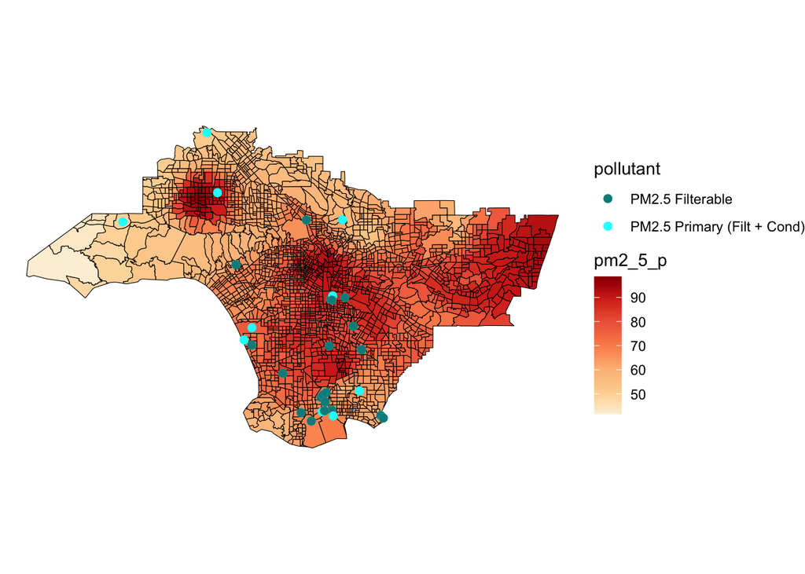

```r
ggplot() +
  # LA map with PM2.5 fill
  geom_sf(data = final_enviroscreen, aes(fill = pm2_5_p), color = 'black', size = 0.2, alpha = 1) +

  # Add facility points with customized colors
  geom_sf(data = top_point_sources, aes(color = pollutant), size = 2, alpha = 1) +

  # Fill scale for PM2.5
  scale_fill_distiller(palette = "OrRd", direction = 1, na.value = "gray90") +

  # Color scale for pollutant types
  scale_color_manual(
    values = c(
      "PM2.5 Primary (Filt + Cond)" = "cyan",
      "PM2.5 Filterable" = "cyan4"
    )
  ) +

  # Minimalist theme
  theme_void()
```

### 3.1.3 Visualize by Source Type

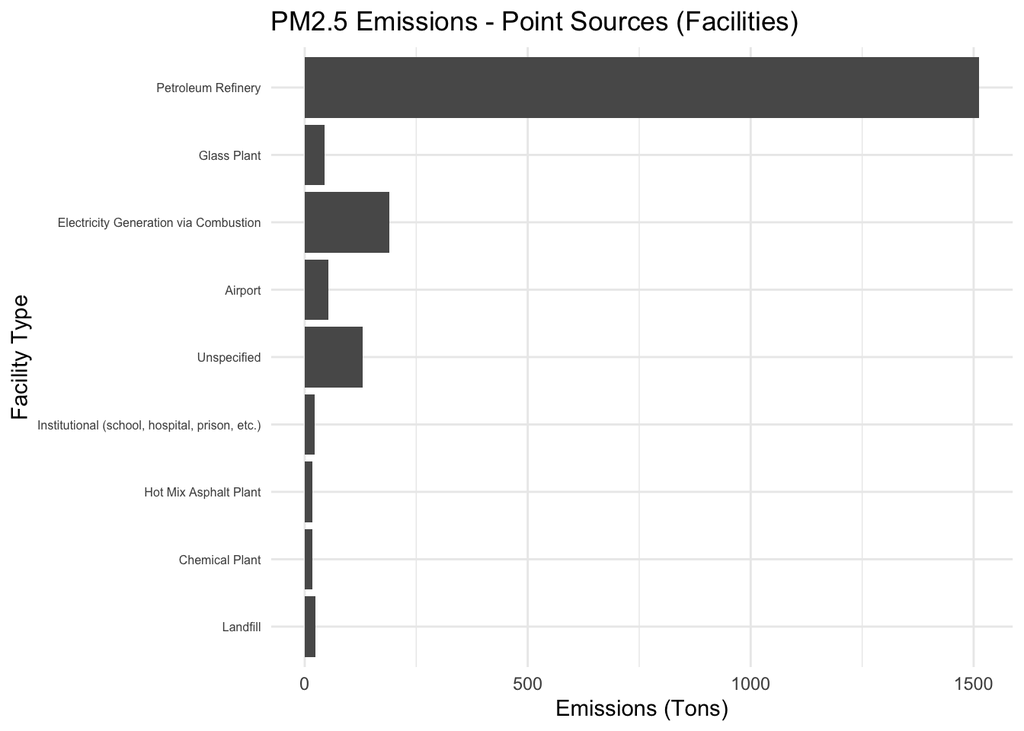

```r
point_sources_plot <- ggplot(top_point_sources, aes(x = reorder(facility_type, emissions_tons), y = emissions_tons)) +
  geom_col() +
  coord_flip() +
  labs(
    title = "PM2.5 Emissions - Point Sources (Facilities)",
    x = "Facility Type",
    y = "Emissions (Tons)"
  ) +
  theme_minimal() +
  theme(
    axis.text.y = element_text(size = 6)
  )

point_sources_plot
```

## 3.2 Non-point Sources

### 3.2.1 Tidy

```r
nonpoint_sources <- read.csv(here("data/sources/nonpoint_sources_2020.csv")) %>%
  clean_names()

nonpoint_sources <- nonpoint_sources %>%
  filter(pollutant %in% c("PM2.5 Primary (Filt + Cond)", "PM2.5 Filterable")) %>%

#convert emissions_tons to numeric
  mutate(emissions_tons = as.numeric(emissions_tons)) %>%
  drop_na()

# filter for top 50 emitters
top_nonpoint_sources <- nonpoint_sources %>%
  filter(emissions_tons > 6.1)

# filter for major sources only
major_nonpoint_sources <- nonpoint_sources %>%
  filter(emissions_tons >= 100)
```

### 3.2.2 Visualize by Source Type

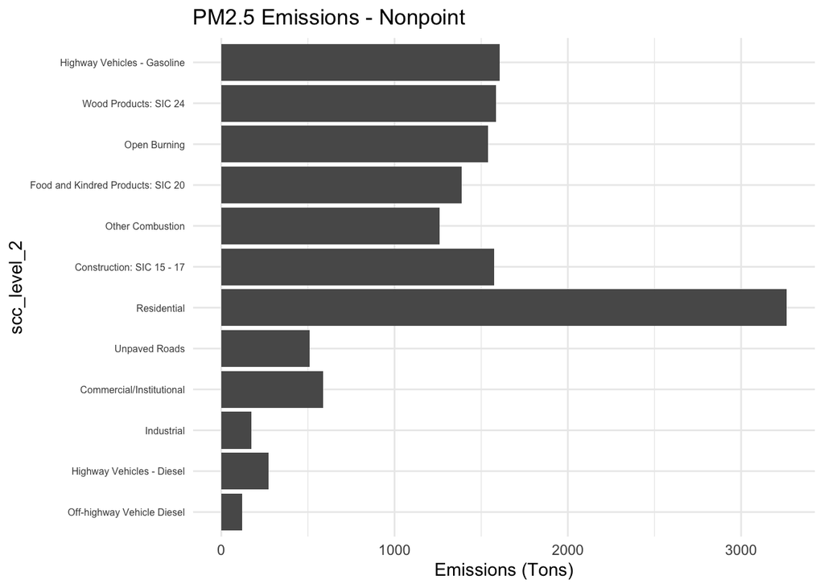

```r
nonpoint_sources_plot <- ggplot(major_nonpoint_sources, aes(x = reorder(scc_level_2, emissions_tons), y = emissions_tons)) +
  geom_col() +
  coord_flip() +
  labs(
    title = "PM2.5 Emissions - Nonpoint",
    x = "scc_level_2",
    y = "Emissions (Tons)"
  ) +
  theme_minimal() +
  theme(
    axis.text.y = element_text(size = 6)
  )

nonpoint_sources_plot
```

# 4 Q&A:

1. What have you learned about your data? Have any potentially interesting patterns emerged?

   I’ve learned that the main pollutant trends closely follow the overall AQI trend, making it redundant to visualize multiple pollutants in the same way. This insight shifted my approach to a more structured, zoomed-in analysis. I plan to start with a broad view by showing the general air quality trend over time in Los Angeles. From there, I’ll highlight which pollutants contribute the most to poor air quality—particularly PM 2.5. Next, I’ll map PM 2.5 concentrations across Los Angeles to identify hotspots, incorporating environmental justice considerations. Finally, I’ll explore the sources of these pollutants to better understand their origins.

   Overall air quality in Los Angeles has improved over time but appears to have plateaued in recent years. While reductions in pollution levels are evident, major air pollution events (such as the Bobcat Fire in 2020) stand out as significant spikes in the data.
2. In HW #1, you outlined some questions that you wanted to answer using these data. Have you made any strides towards answering those questions? If yes, how so? If no, what next steps do you need to take (e.g. I need to create X plot type, I still need to track down Y data, I need to restructure existing data so that you can visualize it in Z ways, etc.)?

   Yes, I’ve made strides toward answering these questions, although my focus has shifted a bit since exploring the data. I now know the overall trends, the largest pollutants, where they are located.
3. What challenges do you foresee encountering with your data? These can be data wrangling and / or visualization challenges.

   I foresee challenges in integrating multiple layers of analysis into a cohesive narrative. While each component—AQI trends, pollutant breakdown, spatial mapping, and source attribution—is insightful on its own, ensuring a cohesive story and maintaining clarity will be important.